# Assignment 1

Jeremy Chan

2026-02-10

## Introduction to the study

In this assignment, we will be analysing the bulk RNA-seq data from GEO accession [`GSE253464`](https://www.ncbi.nlm.nih.gov/geo/query/acc.cgi), published as part of a study by Martell et al. (2025). The study shows that after temozolomide treatment plus radiation (TMZ‑RT), surviving glioblastoma (GBM) cells up‑regulate key genes MPC1/MPC2, which leads to a consequent up-reguation of PC, and down-regulation of PDH activity. This reduces acetyl-CoA production, down-regulating neural differentiation genes NEUROD1 and DCX, leading to undifferentiated and aggressive GBM cells. However, MPC inhibition through metabolic interventions like UK-5099, in a post‑TMZ‑RT state reverses these changes, restoring NEUROD1/DCX expression to limit recurrence.

The main treatment conditions tested were therapy-naive GBM cells versus GBM cells exposed to a concurrent TMZ-RT regimen. They also tested metabolic interventions by inhibiting MPC with UK-5099, both alone and adjuvant after TMZ-RT.

This study and dataset is of interest to me because my current research project with Dr. Federico Gaiti also focuses on glioblastoma and the recurrent property of the cancer, as our attempts are in resolving primary from recurrent tumour cell families in phylogenies.

## Installing relevant packages

First, I made sure to install all the packages that I will be using for the rest of the analysis.

```r
if(!requireNamespace("knitr", quietly = TRUE)) {
  install.packages("knitr")
}

if(!requireNamespace("dplyr", quietly = TRUE)) {
  install.packages("dplyr")
}

if(!requireNamespace("readr", quietly = TRUE)) {
  install.packages("readr")
}

if(!requireNamespace("rmarkdown", quietly = TRUE)) {
  install.packages("rmarkdown")
}

if(!requireNamespace("tidyr", quietly = TRUE)) {
  install.packages("tidyr")
}

if(!requireNamespace("patchwork", quietly = TRUE)) {
  install.packages("patchwork")
}

if(!requireNamespace("ggplot2", quietly = TRUE)) {
  install.packages("ggplot2")
}

if(!requireNamespace("ggrepel", quietly = TRUE)) {
  install.packages("ggrepel")
}

if(!requireNamespace("ComplexHeatmap", quietly = TRUE)) {
  install.packages("ComplexHeatmap")
}

if(!requireNamespace("circlize", quietly = TRUE)) {
  install.packages("circlize")
}

if(!requireNamespace("tibble", quietly = TRUE)) {
  install.packages("tibble")
}

if(!requireNamespace("BiocManager", quietly = TRUE)) {
  install.packages("BiocManager")
}

if(!requireNamespace("biomaRt", quietly = TRUE)) {
  BiocManager::install("biomaRt")
}

if(!requireNamespace("GEOquery", quietly = TRUE)) {
  BiocManager::install("GEOquery")
}

if(!requireNamespace("edgeR", quietly = TRUE)) {
  BiocManager::install("edgeR")
}
```

## Obtaining, cleaning, and mapping data

In this section, I will first pull the data from the GEO database. I will then clean the data by dealing with duplicate and incorrectly formatted genes, then demonstrate identifier mapping.

### Pulling data in from GEO

To begin, I will use the `GEOquery` package to obtain the raw count data from the GSE database.

```r
# Load in the relevant libraries
library("GEOquery")
library("readr")
library("rmarkdown")
library("knitr")

# Check if the GEO data has already been pulled in; if not then get data files
if(!file.exists("GSE253464/GSE253464_counts.unnormalized.csv.gz")) {
  getGEOSuppFiles("GSE253464", makeDirectory = TRUE)
}

# Read in the raw counts
raw_counts <- read_csv("GSE253464/GSE253464_counts.unnormalized.csv.gz", show_col_types = FALSE)

# Display the first 10 columns and rows for report
paged_table(raw_counts[1:10, 1:10])
```

| Geneid | Chr | Start | End | Strand | Length | BT935_Naive_01_S4 | BT935_Naive_02_S2 | BT935_Naive_03_S3 | BT935_TMZRT_01_S7 |
| --- | --- | --- | --- | --- | --- | --- | --- | --- | --- |
| DDX11L1 | NC_000001.11;NC_000001.11;NC_000001.11 | 11874;12613;13221 | 12227;12721;14409 | +;+;+ | 1652 | 0 | 0 | 1 | 0 |
| WASH7P | NC_000001.11;NC_000001.11;NC_000001.11;NC_000001.11;NC_000001.11;NC_000001.11;NC_000001.11;NC_000001.11;NC_000001.11;NC_000001.11;NC_000001.11 | 14362;14970;15796;16607;16858;17233;17606;17915;18268;24738;29321 | 14829;15038;15947;16765;17055;17368;17742;18061;18366;24891;29370 | -;-;-;-;-;-;-;-;-;-;- | 1769 | 194 | 109 | 100 | 72 |
| MIR6859-1 | NC_000001.11;NC_000001.11;NC_000001.11 | 17369;17369;17409 | 17436;17391;17431 | -;-;- | 68 | 21 | 7 | 9 | 7 |
| MIR1302-2HG | NC_000001.11;NC_000001.11;NC_000001.11 | 29774;30976;34168 | 30667;31093;35418 | +;+;+ | 2263 | 2 | 0 | 1 | 0 |
| MIR1302-2 | NC_000001.11;NC_000001.11 | 30366;30438 | 30503;30458 | +;+ | 138 | 0 | 0 | 0 | 0 |
| FAM138A | NC_000001.11;NC_000001.11;NC_000001.11 | 34611;35277;35721 | 35174;35481;36081 | -;-;- | 1130 | 0 | 0 | 0 | 0 |
| OR4F5 | NC_000001.11;NC_000001.11;NC_000001.11 | 65419;65520;69037 | 65433;65573;71585 | +;+;+ | 2618 | 0 | 0 | 0 | 0 |
| LOC124903816 | NC_000001.11;NC_000001.11;NC_000001.11;NC_000001.11;NC_000001.11 | 95222;95222;106636;106636;106954 | 99719;99719;106742;107727;107727 | +;+;+;+;+ | 5590 | 0 | 0 | 0 | 0 |
| LOC124900384 | NC_000001.11;NC_000001.11;NC_000001.11;NC_000001.11;NC_000001.11;NC_000001.11;NC_000001.11;NC_000001.11;NC_000001.11;NC_000001.11;NC_000001.11;NC_000001.11;NC_000001.11;NC_000001.11;NC_000001.11;NC_00… | 120849;146300;146301;146435;146470;149034;149035;149035;151857;153076;153354;153354;153354;153674;153720;155767;155767;155767;155767;155767;155767;155767;155767;155767;155767;155767;158518;158593;1585… | 120932;146339;146339;146509;146509;149072;149072;149072;152360;153543;153543;153543;153543;153713;154017;155831;155831;155831;155831;155831;155831;155831;155831;155831;155831;155831;158674;158674;1586… | -;-;-;-;-;-;-;-;-;-;-;-;-;-;-;-;-;-;-;-;-;-;-;-;-;-;-;-;-;-;-;-;-;-;-;-;-;-;-;-;-;-;-;-;-;-;-;-;-;-;-;-;-;-;-;-;-;-;-;-;-;-;-;-;-;-;-;-;-;-;-;-;-;-;-;-;-;-;-;-;-;-;-;-;-;-;-;-;-;-;-;-;-;-;-;-;-;-;-;-;… | 4266 | 3 | 0 | 1 | 0 |
| LOC729737 | NC_000001.11;NC_000001.11;NC_000001.11 | 134773;139790;140075 | 139696;139847;140566 | -;-;- | 5474 | 3 | 0 | 0 | 3 |

**Table 1: Unnormalised read counts of GSE253646.** Table showing the unnormalised read counts of each samples (columns 7 to 18) for each gene (row). Columns 2 to 6 of the table has additional information about each gene including their chromosomal position, strand orientation, and gene length. Displayed table is truncated to 10 rows and 10 columns for visibility.

### Quality control and cleaning of data

Next, I will summarise the overall statistics of the data as well as look over it to make sure that we move on with the correct gene dataset for the upcoming steps.

```r
# Remove chromosomal positions, strand information, and length
counts <- raw_counts[, -(2:6)]

num_samples <- ncol(counts) - 1 # Number of samples
lib_sizes <- colSums(counts[, 2:ncol(counts)], na.rm = TRUE) # Get library size for each sample
lib_sizes <- as.data.frame(lib_sizes)

counts$Geneid_clean <- sub("_[0-9]+$", "", counts$Geneid) # Get original HGNC symbol, some confounded by numbers
num_genes <- nrow(counts)
num_unique_genes <- nrow(unique(counts["Geneid"])) # Get unique number of genes

# Display library size in report
paged_table(lib_sizes)
```

|  | lib_sizes |
| --- | --- |
| BT935_Naive_01_S4 | 41906773 |
| BT935_Naive_02_S2 | 17661540 |
| BT935_Naive_03_S3 | 21060423 |
| BT935_TMZRT_01_S7 | 15705450 |
| BT935_TMZRT_02_S8 | 15633454 |
| BT935_TMZRT_03_S5 | 39503685 |
| BT935_TMZRT_UK5099_01_S10 | 14132742 |
| BT935_TMZRT_UK5099_02_S11 | 14995151 |
| BT935_TMZRT_UK5099_03_S12 | 13151306 |
| BT935_UK5099_01_S4 | 18751131 |

[output cut: 2 more lines]

**Table 2: Library size of each sample.** Table showing the library size for each sample, where the first column is the sample name and the second column is the sum of read counts across all genes that were sequenced for that sample.

I will handle replicates by keeping all samples as separate observations rather than averaging counts within each treatment group. This will improve statistical power and provides more reliable differential expression testing.

Now that I know that there are some genes that correspond to multiple rows on the dataset, I opted to sum their read counts and then remove the duplicate rows.

```r
# Load in relevant libraries
library("dplyr")

# Identify which columns are the sample count columns
count_cols <- setdiff(colnames(counts), c("Geneid", "Geneid_clean"))

# Sum counts for duplicated genes (same Geneid_clean)
counts_summed <- counts %>%
  group_by(Geneid_clean) %>%
  summarise(
    Geneid = first(Geneid), # keep one representative original ID
    across(all_of(count_cols), ~ sum(.x, na.rm = TRUE)),
    .groups = "drop"
  ) %>%
  relocate(Geneid, Geneid_clean)

# Replace counts with the deduplicated/summed version
counts <- counts_summed
```

This leaves us with 43797 genes, removing 5928 duplicate rows.

There are also some genes that appear to be formatted incorrectly - their HGNC ID has only numerical characters, and their formatting appears to be wrong on the table. I will remove these rows and genes from the table.

```r
# Get number of genes whose HGNC symbols are only numbers
num_numeric <- sum(grepl("^[0-9]+$", counts$Geneid_clean))

# Filter out genes whose HGNC symbols are only numbers
counts <- counts %>%
  filter(!grepl("^[0-9]+$", Geneid_clean))
```

This leaves us with 43784 genes remaining in the dataset. There are some genes that appear to be zero in all samples, but we will not remove them for now as we will be filtering out lowly expressed genes in the upcoming steps.

### Mapping to HUGO symbols

The initial dataset from GEO uses the HGNC symbols for its gene IDs, so all genes have a corresponding HUGO symbol. However, I will demonstrate identifier mapping by mapping the HGNC symbols to its corresponding ensembl gene ID(s), if they exist.

```r
# Load in relevant libraries
library("biomaRt")

# Get HGNC symbols as a column of a dataframe
symbols <- counts$Geneid_clean

# Use the homosapiens gene ensembl biomaRt
ensembl <- useMart("ensembl")
ensembl <- useDataset("hsapiens_gene_ensembl", mart = ensembl)

# Map the HGNC symbols to the ensembl gene IDs
map <- getBM(
  attributes = c("hgnc_symbol", "ensembl_gene_id"),
  filters = "hgnc_symbol",
  values = symbols,
  mart = ensembl
)

# Get HGNC symbols as an array of string
symbols <- counts[2]

# Remove all duplicates (some HGNC symbols have multiple ensembl gene IDs) for display's sake
symbols_map <- symbols %>%
  left_join(map, by = c("Geneid_clean" = "hgnc_symbol")) %>%
  group_by(Geneid_clean) %>%
  slice(1) %>%
  ungroup()

# Rename columns
colnames(symbols_map) <- c("HGNC symbol", "ensembl gene ID")

# Display the first 20 genes with their HGNC symbol and ensembl gene IDs for report
paged_table(symbols_map[1:20, ])
```

| HGNC symbol | ensembl gene ID |
| --- | --- |
| A1BG | ENSG00000121410 |
| A1BG-AS1 | ENSG00000268895 |
| A1CF | ENSG00000148584 |
| A2M | ENSG00000175899 |
| A2M-AS1 | ENSG00000245105 |
| A2ML1 | ENSG00000166535 |
| A2MP1 | ENSG00000256069 |
| A3GALT2 | ENSG00000184389 |
| A4GALT | ENSG00000128274 |
| A4GNT | ENSG00000118017 |

[output cut: 10 more lines]

**Table 3: Identifier mapping from HGNC symbol to ensembl gene ID.** Table shows the HGNC symbols that are in the initial dataset along with their corresponding ensembl gene ID. For HGNC symbols that have multiple ensembl gene IDs, only the first one was kept for visualisation purposes. Table is truncated to the first 20 genes for visualisation purposes.

There are a number of genes that do not have corresponding ensembl gene IDs. However, I have opted to not remove them because the ensembl database only updates periodicially (once every 3 months), while the HGNC updates nearly daily to include more novel genes. Removing such genes may prevent discovering hypothetical functions of novel genes in the upcoming steps.

## Normalisation of data

I will normalise the data now to minimise unwanted variation in the data, such as difference in library sizes (as shown above) and in how reads are distributed between genes.

### Defining groups

My first step in normalisation is to separate the groups. The main groups that were mentioned in the paper are the different treatment types. I will separate each sample by its treatment, and its replicate number just in case I need to use it in future steps.

```r
# Get the names of each sample
sample_names <- colnames(counts)[3:ncol(counts)]

# Separate the names by "_" to extract replicate number and treatment
samples <- data.frame(sample = sample_names) %>%
  dplyr::mutate(
    parts = strsplit(sample, "_"),
    replicate = sapply(parts, function(x) x[length(x) - 1]),
    treatment = sapply(parts, function(x) paste(x[2:(length(x) - 2)], collapse = "_"))
  ) %>%
  dplyr::select(sample, treatment, replicate)

# Display the table
paged_table(samples)
```

| sample | treatment | replicate |
| --- | --- | --- |
| BT935_Naive_01_S4 | Naive | 01 |
| BT935_Naive_02_S2 | Naive | 02 |
| BT935_Naive_03_S3 | Naive | 03 |
| BT935_TMZRT_01_S7 | TMZRT | 01 |
| BT935_TMZRT_02_S8 | TMZRT | 02 |
| BT935_TMZRT_03_S5 | TMZRT | 03 |
| BT935_TMZRT_UK5099_01_S10 | TMZRT_UK5099 | 01 |
| BT935_TMZRT_UK5099_02_S11 | TMZRT_UK5099 | 02 |
| BT935_TMZRT_UK5099_03_S12 | TMZRT_UK5099 | 03 |
| BT935_UK5099_01_S4 | UK5099 | 01 |

[output cut: 2 more lines]

**Table 4: Sample by its treatment group and replicate number.** Table shows the full sample name (column 1), as well the extracted treatment names/groups that it is part of (column 2), and the replicate number in its respective group (column 3).

### Apply TMM normalisation

We normalized the bulk RNA-seq counts using the TMM (Trimmed Mean of M-values) method in `edgeR`. TMM corrects for differences in sequencing depth and compositional bias by trimming genes with extreme fold-changes and extreme expression before estimating scaling factors. This is preferred over methods such as RPKM/FPKM for differential expression because those approaches do not robustly correct for composition bias, potentially creating inaccurate results during the future steps.

In this step, we will also filter out lowly expressed genes using `edgeR`’s `filterByExpr()` function. This will remove genes that have relatively low read counts, as was mentioned during the cleaning steps above. This resulted in 15,630 genes being kept across 12 samples, filtering out 28,154 lowly expressed genes.

```r
# Load in relevant libraries
library("edgeR")

# Create count-only matrix
cleaned_data_matrix <- counts[, 3:ncol(counts)] # Remove gene ID columns
rownames(cleaned_data_matrix) <- counts$Geneid_clean # Add gene IDs as row names instead

# Make each treatment a factor (level)
samples$treatment <- factor(samples$treatment)

# Create a DGEList object
d <- DGEList(counts = as.matrix(cleaned_data_matrix),
                    group = samples$treatment)

# Filter out lowly expressed genes
keep <- filterByExpr(d, group = samples$treatment)
d <- d[keep, , keep.lib.sizes = FALSE]

# Calculate scaling factors for normalisation through TMM
d <- calcNormFactors(d, method = "TMM")

# Get counts per million of scaling factors
normalised_counts <- cpm(d)

# Display first 10 rows and columns of normalised counts for report
df_normalised_counts <- as.data.frame(normalised_counts) # Convert to dataframe first so paged_table can be used
paged_table(df_normalised_counts[1:10, 1:10])
```

|  | BT935_Naive_01_S4 | BT935_Naive_02_S2 | BT935_Naive_03_S3 | BT935_TMZRT_01_S7 | BT935_TMZRT_02_S8 | BT935_TMZRT_03_S5 | BT935_TMZRT_UK5099_01_S10 | BT935_TMZRT_UK5099_02_S11 | BT935_TMZRT_UK5099_03_S12 | BT935_UK5099_01_S4 |
| --- | --- | --- | --- | --- | --- | --- | --- | --- | --- | --- |
| A1BG | 4.3621275 | 3.3355340 | 4.0869140 | 4.275176 | 4.086704 | 4.4610792 | 5.4584589 | 5.022428 | 5.599496 | 6.0584900 |
| A1BG-AS1 | 2.0807850 | 2.6803398 | 1.3456912 | 2.424726 | 1.851788 | 1.9937784 | 2.1419269 | 1.826338 | 1.915617 | 2.5287611 |
| A2M | 160.5212779 | 156.7700983 | 154.2560834 | 390.763808 | 366.462418 | 371.7150601 | 321.4272275 | 295.866684 | 300.236123 | 97.5153484 |
| A2M-AS1 | 0.4011152 | 0.4169418 | 0.2990425 | 0.319043 | 0.510838 | 0.5981335 | 0.8982274 | 0.195679 | 0.515743 | 0.7375553 |
| A4GALT | 69.9444581 | 72.2500491 | 70.0257826 | 77.144586 | 69.282405 | 74.1685564 | 41.0420837 | 41.027369 | 45.606420 | 22.9168971 |
| AACS | 38.4318474 | 38.4777673 | 37.3803110 | 53.407790 | 48.976594 | 49.9441489 | 51.2680574 | 46.506381 | 47.743069 | 39.8806692 |
| AADAT | 15.7939099 | 14.1164564 | 14.6032415 | 9.954140 | 11.174581 | 10.6168700 | 11.0551067 | 10.566667 | 10.093828 | 12.7491704 |
| AAGAB | 117.5768848 | 109.1791756 | 118.0719424 | 95.840503 | 103.827826 | 99.1406309 | 100.1869045 | 102.274903 | 102.780219 | 100.7289823 |
| AAK1 | 144.9028559 | 143.7853409 | 149.1723611 | 145.675012 | 147.568330 | 147.4897570 | 139.5707222 | 130.452683 | 130.777698 | 123.5931969 |
| AAMDC | 7.8217459 | 8.5175243 | 8.1738280 | 10.081757 | 10.536034 | 9.2959918 | 10.7096346 | 9.262140 | 12.156800 | 9.6935841 |

**Table 5: Normalised read counts for each sample and gene.** Table of gene expression values after TMM normalization, reported as counts-per-million (CPM). These normalized values correct for differences in library size and compositional bias across samples, allowing expression levels to be accurately compared across treatment conditions.

### Comparison of plots

Now that I have the normalised data, I will now plot boxplots and density plots to visualise the difference between the raw versus normalised counts.

```r
# Load in relevant libraries
library("ggplot2")
library("tidyr")
library("patchwork")

# Convert the raw counts matrix into a long format (one row per gene-sample), then join metadata
raw_long <- as.data.frame(counts[, 3:ncol(counts)]) %>%
  pivot_longer(cols = everything(), names_to = "sample", values_to = "count") %>%
  left_join(samples, by = "sample") %>%
  mutate(type = "Raw")

# Convert the normalised counts matrix into a long format (one row per gene-sample), then join metadata
norm_long <- as.data.frame(normalised_counts) %>%
  pivot_longer(cols = everything(), names_to = "sample", values_to = "count") %>%
  left_join(samples, by = "sample") %>%
  mutate(type = "TMM normalized")
```

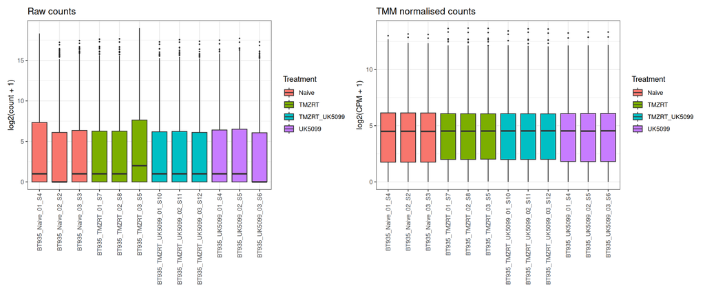

```r
# Create boxplot for both the raw and normalised count data
p_raw_box <- ggplot(raw_long, aes(x = sample, y = log2(count + 1), fill = treatment)) +
  geom_boxplot(outlier.size = 0.4) +
  theme_bw() +
  theme(axis.text.x = element_text(angle = 90, vjust = 0.5, hjust = 1)) +
  labs(title = "Raw counts", y = "log2(count + 1)", x = "", fill = "Treatment")

p_norm_box <- ggplot(norm_long, aes(x = sample, y = log2(count + 1), fill = treatment)) +
  geom_boxplot(outlier.size = 0.4) +
  theme_bw() +
  theme(axis.text.x = element_text(angle = 90, vjust = 0.5, hjust = 1)) +
  labs(title = "TMM normalised counts", y = "log2(CPM + 1)", x = "", fill = "Treatment")

# Combine the two boxplots together for easy comparison
p_raw_box + p_norm_box
```

**Figure 1: Boxplots of raw and TMM normalised expression values across samples.** Each box represents the distribution of gene expression values within a single sample. The left panel shows raw read counts on a log2(count + 1) scale, and the right panel shows TMM normalised counts-per-million (CPM) on a log2(CPM + 1) scale. Samples are coloured by treatment group (red = Naive, green = TMZRT, cyan = TMZRT + UK5099, purple = UK5099). The horizontal line in each box is the median, the box spans the interquartile range, and points represent outliers.

From the raw counts boxplots (left) in Figure 1, the samples show noticeable differences in their overall count distributions, which is expected because sequencing depth and RNA composition can vary between samples/libraries. After applying TMM normalization (right), the IQR and mean of the boxplots become more aligned across samples, indicating that scaling factors have adjusted for library size and compositional bias. Filtering out lowly expressed genes also moved all IQRs to not include 0. This will improve comparability between samples and supports using the normalized data for the upcoming downstream analyses, such as MDS visualization and differential expression testing.

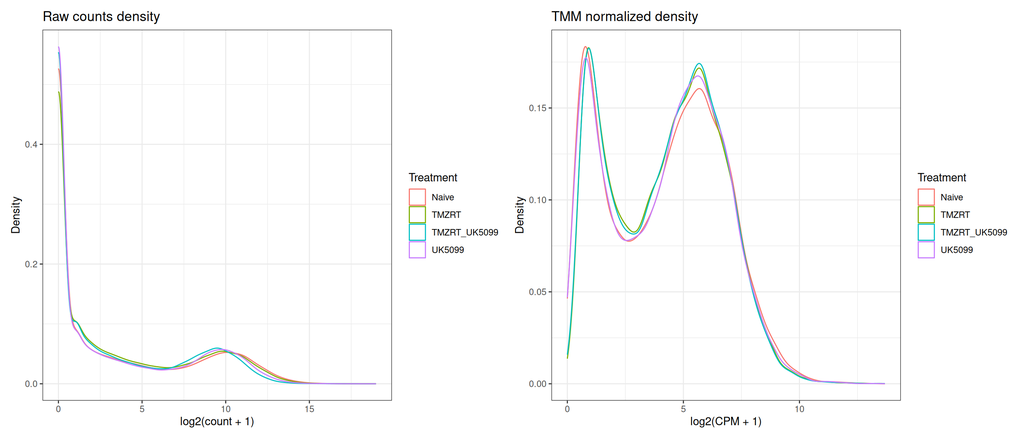

```r
# Create density plot for both the raw and normalised count data
p_raw_den <- ggplot(raw_long, aes(x = log2(count + 1), colour = treatment)) +
  geom_density() +
  theme_bw() +
  labs(title = "Raw counts density", x = "log2(count + 1)", y = "Density", colour = "Treatment")

p_norm_den <- ggplot(norm_long, aes(x = log2(count + 1), colour = treatment)) +
  geom_density() +
  theme_bw() +
  labs(title = "TMM normalized density", x = "log2(CPM + 1)", y = "Density", colour = "Treatment")

# Combine the two density plots together for easy comparison
p_raw_den + p_norm_den
```

Within Figure 2, in the raw counts density plot (left), the curves show small shifts between samples, reflecting differences in sequencing depth and RNA composition. After TMM normalisation (right), the density curves indicate the decrease in frequency in lowly expressed genes. This, along with the boxplots, supports the use of the normalised CPM values for the upcoming downstream exploratory analyses and differential expression testing.

## Differential expression analysis

With the normalised data, I will now move on to conducting differential expression (DE) analysis to see if the genes of interest are up- or down-regulated when comparing naive cells to treatment conditions.

### Factoring by MDS plot

The first step in DE is to make sure we are choosing the correct factor when making our design matrix. We will do this by plotting a multidimensional scaling (MDS) plot to visualise how the samples cluster.

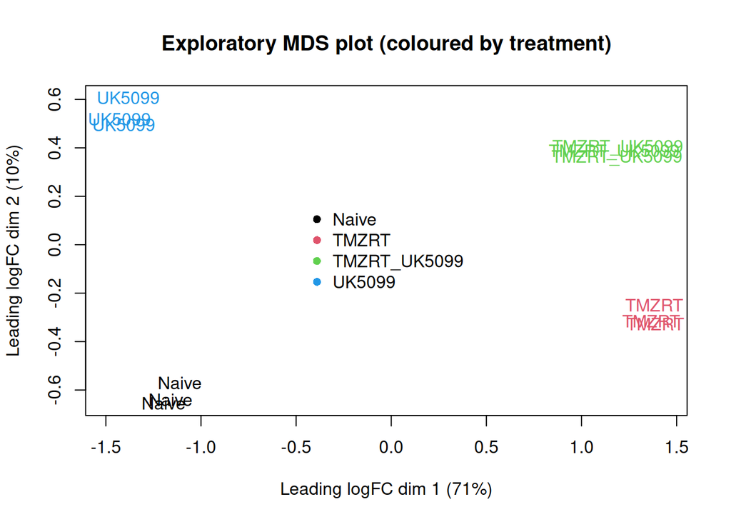

```r
# Plot the MDS plot by treatment
plotMDS(d,
        labels = samples$treatment,
        col = as.numeric(samples$treatment),
        main = "Exploratory MDS plot (coloured by treatment)")

# Add legend mapping to treatment
legend("center",
       legend = levels(samples$treatment),
       col = seq_along(levels(samples$treatment)),
       pch = 16,
       bty = "n")
```

**Figure 3: Exploratory multi-dimensional scaling (MDS) plot of RNA-seq samples coloured by treatment.** Each point represents one RNA-seq sample, positioned based on overall similarity in gene expression profiles (samples closer together have more similar expression patterns). The x-axis (Leading logFC dim 1) and y-axis (Leading logFC dim 2) represent the two dimensions capturing the largest sources of variation across the dataset, with the percentage values indicating the proportion of variation explained by each dimension. Points are coloured and labelled according to treatment group (black = Naive, red = TMZRT, green = TMZRT + UK5099, blue = UK5099).

Figure 3 shows that samples cluster primarily by treatment condition, with replicates from the same treatment grouping closely together. This indicates that treatment is a major driver of expression differences in the dataset. Therefore, treatment will be used as the main grouping variable in the design matrix for downstream differential expression analysis.

### Creating and testing design matrix

I will create the design matrix now, grouping by treatment.

```r
# Create design matrix
design <- model.matrix(~ 0 + treatment, data = samples)
colnames(design) <- levels(samples$treatment) # Name the columns accordingly to treatment

edge <- estimateDisp(d, design) # Estimate dispersions
fit <- glmQLFit(d, design) # Fit quasi-lieklihood
```

Next, I tested for differential expression between treatment conditions using `edgeR`’s quasi-likelihood (QL) framework. We defined a set of contrasts between treatment conditions and ran QL F-tests to obtain gene-level test statistics and raw p-values for each comparison. For each contrast, we extracted the full results table containing log2 fold-change (logFC), average expression (logCPM), the test statistic, the raw p-value (PValue), and the multiple-hypothesis-testing adjusted p-value (FDR).

I corrected p-values using the Benjamini-Hochberg false discovery rate (FDR) method, which is the standard approach for RNA-seq because thousands of genes are tested simultaneously. FDR controls the expected proportion of false positives among the genes called significant, providing a balance between sensitivity and error control. I preferred over more conservative methods such as Bonferroni correction, which can greatly reduce power in high-dimensional genomic datasets such as this. If I used Bonferroni correction, it could greatly reduce the number of differentially expressed genes that will be present in our dataset for the upcoming DE step.

```r
library("tibble")

# Define contrasts between each treatment
contrasts <- makeContrasts(
  `TMZRT_vs_Naive` = TMZRT - Naive,
  `UK5099_vs_Naive` = UK5099 - Naive,
  `TMZRT_UK5099_vs_Naive` = TMZRT_UK5099 - Naive,
  `TMZRT_UK5099_vs_TMZRT` = TMZRT_UK5099 - TMZRT,
  levels = design
)

# Run quasi-likelihood F-tetsts for each contrast
qlf_tmzrt_vs_naive <- glmQLFTest(fit,
                                 contrast = contrasts[, "TMZRT_vs_Naive"])
qlf_uk_vs_naive <- glmQLFTest(fit,
                              contrast = contrasts[, "UK5099_vs_Naive"])
qlf_combo_vs_naive <- glmQLFTest(fit,
                                 contrast = contrasts[, "TMZRT_UK5099_vs_Naive"])
qlf_combo_vs_tmzrt <- glmQLFTest(fit,
                                 contrast = contrasts[, "TMZRT_UK5099_vs_TMZRT"])

# Extract full results tables for each contrast
tab_tmzrt_vs_naive <- topTags(qlf_tmzrt_vs_naive, n = Inf)$table %>%
  rownames_to_column("gene")
tab_uk_vs_naive <- topTags(qlf_uk_vs_naive, n = Inf)$table %>%
  rownames_to_column("gene")
tab_combo_vs_naive <- topTags(qlf_combo_vs_naive, n = Inf)$table %>%
  rownames_to_column("gene")
tab_combo_vs_tmzrt <- topTags(qlf_combo_vs_tmzrt, n = Inf)$table %>%
  rownames_to_column("gene")
```

To summarize the results, I counted how many genes were significant under a standard raw p-value threshold (PValue < 0.05). Because thousands of genes are tested simultaneously, we also reported the number of genes passing multiple hypothesis correction using the false discovery rate threshold (FDR < 0.05). These counts were calculated for each contrast and combined into a summary table for reporting.

```r
# Helper function to count how many genes pass p-value and FDR threshold (both < 0.05 = significant)
count_de <- function(tab, p_thresh = 0.05, fdr_thresh = 0.05, logfc_thresh = 1) {
  out <- list(
    n_tested = nrow(tab),
    n_p = sum(tab$PValue < p_thresh, na.rm = TRUE),
    n_fdr = sum(tab$FDR < fdr_thresh, na.rm = TRUE)
  )
  return(out)
}

# Count number of significant genes for each contrast
de_tmzrt_vs_naive <- count_de(tab_tmzrt_vs_naive)
de_uk_vs_naive <- count_de(tab_uk_vs_naive)
de_combo_vs_naive <- count_de(tab_combo_vs_naive)
de_combo_vs_tmzrt <- count_de(tab_combo_vs_tmzrt)

# Combine all the counts into a summary table for report
de_summary <- data.frame(
  contrast = c("TMZRT vs Naive", "UK5099 vs Naive", "TMZRT_UK5099 vs Naive",
               "TMZRT_UK5099 vs TMZRT"),
  n = c(de_tmzrt_vs_naive$n_tested, de_uk_vs_naive$n_tested,
               de_combo_vs_naive$n_tested, de_combo_vs_tmzrt$n_tested),
  n_p_lt_0.05 = c(de_tmzrt_vs_naive$n_p, de_uk_vs_naive$n_p,
                  de_combo_vs_naive$n_p, de_combo_vs_tmzrt$n_p),
  n_fdr_lt_0.05 = c(de_tmzrt_vs_naive$n_fdr, de_uk_vs_naive$n_fdr,
                    de_combo_vs_naive$n_fdr, de_combo_vs_tmzrt$n_fdr)
)

# Display table for report
paged_table(de_summary)
```

| contrast | n | n_p_lt_0.05 | n_fdr_lt_0.05 |
| --- | --- | --- | --- |
| TMZRT vs Naive | 15630 | 11329 | 11026 |
| UK5099 vs Naive | 15630 | 7811 | 6758 |
| TMZRT_UK5099 vs Naive | 15630 | 11086 | 10752 |
| TMZRT_UK5099 vs TMZRT | 15630 | 4618 | 2774 |

**Table 6: Summary of differential expression results across treatment contrasts.** For each pairwise comparison, the table reports the total number of genes tested (n), the number of genes significant at the raw p-value threshold (PValue < 0.05, n_p_lt_0.05), and the number of genes significant after multiple testing correction using the Benjamini-Hochberg false discovery rate (FDR < 0.05, n_fdr_lt_0.05).

For the downstream analyses, only the genes that pass the FDR test (FDR < 0.05) will be used.

### Volcano plot of each comparison

Now that I have genes that are statistically significant, I will now construct volcano plots that will illustrate which genes that are down-regulated and up-regulated. I focused only on the three treatments versus Naive volcano plots because these comparisons most directly test the study’s main question; how TMZ-RT in combination with metabolic inhibition (UK-5099 treatment) shift gene expression away from the therapy-naive baseline.

Additionally, the paper refers to gene of interest PDH at the level of the enzyme complex rather than a specific subunit, I will highlight the PDHA1 gene in the volcano plots as a representative PDH gene since it encodes the main catalytic E1 alpha subunit.

In the volcano plots, I will highlight the key genes as mentioned. I will also highlight top 10 genes with the lowest FDR that could be used in downstream analyses separate from the aim of this report.

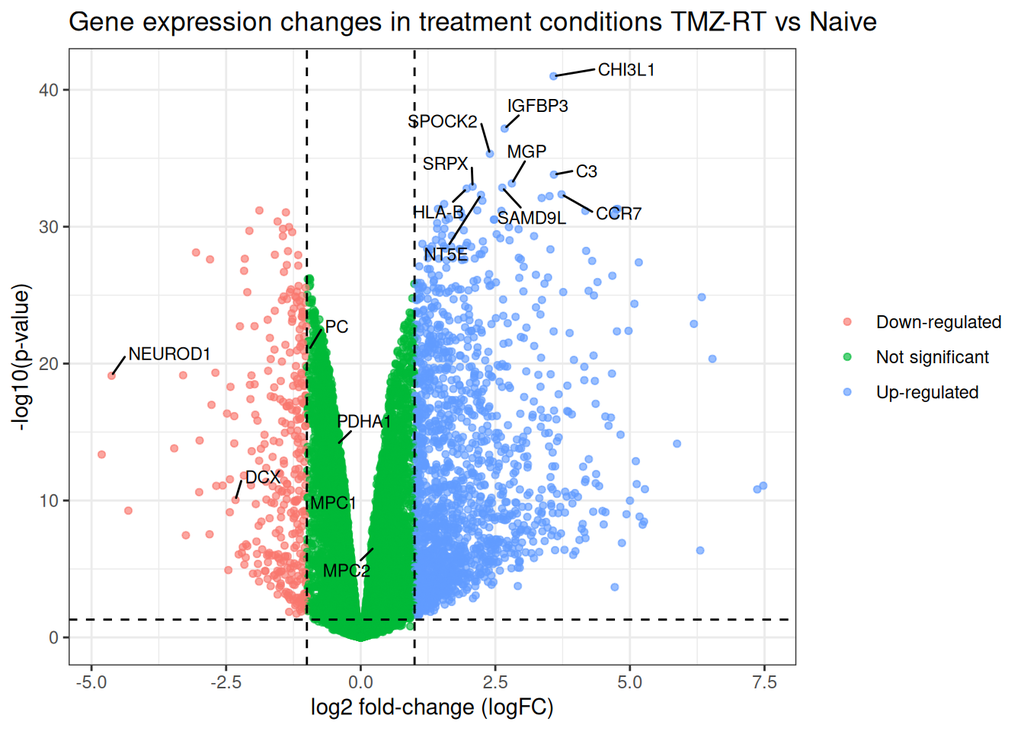

```r
# Load in relevant libraries
library("ggrepel")

# Genes that are of interest in the paper
highlight_genes <- c("NEUROD1", "DCX", "MPC1", "MPC2", "PC", "PDHA1")

# Build volcano plot data, using FDR and log-fold change to determine direction
volcano_df <- tab_tmzrt_vs_naive %>%
  mutate(Significant = FDR < 0.05,
         direction = case_when(
           FDR < 0.05 & logFC > 1 ~ "Up-regulated",
           FDR < 0.05 & logFC < -1 ~ "Down-regulated",
           TRUE ~ "Not significant"))

# Select the top and highlighted genes to label
label_volcano <- volcano_df %>%
  filter(gene %in% highlight_genes | rank(FDR) <= 10)

# Build volcano plot
ggplot(volcano_df, aes(x = logFC, y = -log10(PValue))) +
  geom_point(aes(color = direction), alpha = 0.65, size = 1.3) +
  geom_vline(xintercept = c(-1, 1), linetype = "dashed") +
  geom_hline(yintercept = -log10(0.05), linetype = "dashed") +
  geom_text_repel(data = label_volcano, aes(label = gene), box.padding = 0.5, size = 3, max.overlaps = Inf) +
  theme_bw() +
  labs(
    title = "Gene expression changes in treatment conditions TMZ-RT vs Naive",
    x = "log2 fold-change (logFC)",
    y = "-log10(p-value)",
    color = NULL
  )
```

**Figure 4: Volcano plot of differential expression results for TMZ-RT vs. Naive.** Each point represents one gene tested for differential expression using `edgeR`’s quasi-likelihood framework. The x-axis shows the estimated log2 fold-change between TMZ-RT and therapy-naive conditions, and the y-axis shows the strength of evidence against the null hypothesis of -log10(p-value). Genes are coloured by the direction of change using thresholds of FDR < 0.05 and |logFC| > 1 (up-regulated, down-regulated, or not significant). Dashed vertical lines indicate the fold-change threshold, and the dashed horizontal line indicates the p-value threshold. Selected genes are labelled, including the top 10 hits by FDR and genes of interest from the study (NEUROD1, DCX, MPC1, MPC2, PC, PDHA1).

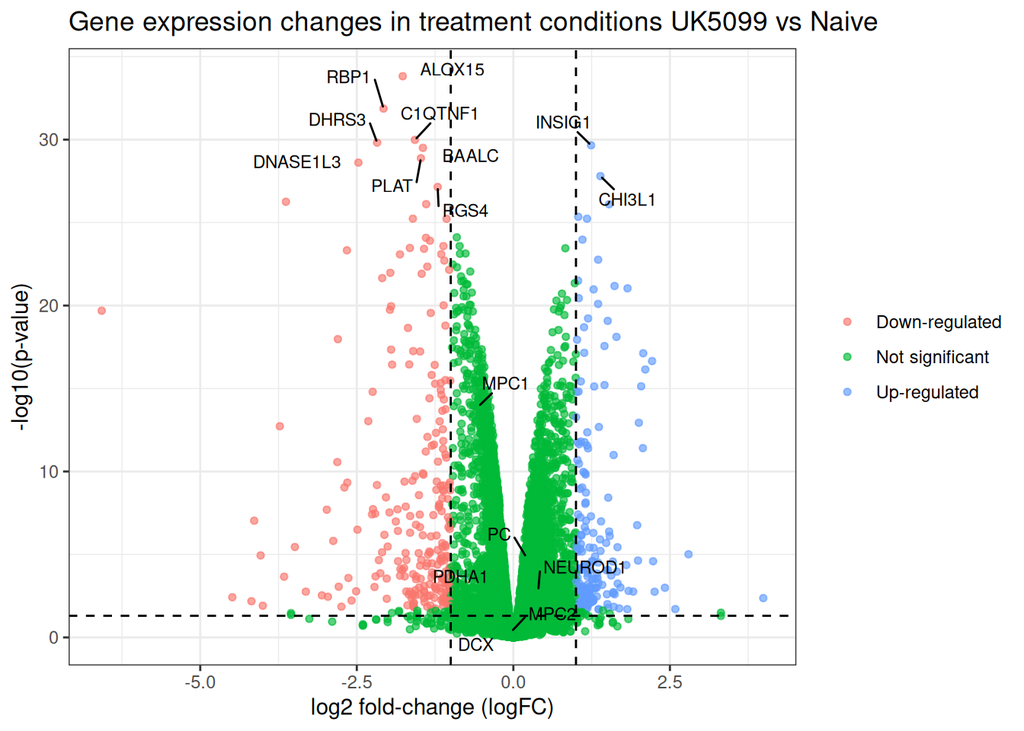

```r
# Build volcano plot data, using FDR and log-fold change to determine direction
volcano_df <- tab_uk_vs_naive %>%
  mutate(Significant = FDR < 0.05,
         direction = case_when(
           FDR < 0.05 & logFC > 1 ~ "Up-regulated",
           FDR < 0.05 & logFC < -1 ~ "Down-regulated",
           TRUE ~ "Not significant"))

# Select the top genes to label
label_volcano <- volcano_df %>%
  filter(gene %in% highlight_genes | rank(FDR) <= 10)

# Build volcano plot
ggplot(volcano_df, aes(x = logFC, y = -log10(PValue))) +
  geom_point(aes(color = direction), alpha = 0.65, size = 1.3) +
  geom_vline(xintercept = c(-1, 1), linetype = "dashed") +
  geom_hline(yintercept = -log10(0.05), linetype = "dashed") +
  geom_text_repel(data = label_volcano, aes(label = gene), size = 3, box.padding = 0.5, max.overlaps = Inf) +
  theme_bw() +
  labs(
    title = "Gene expression changes in treatment conditions UK5099 vs Naive",
    x = "log2 fold-change (logFC)",
    y = "-log10(p-value)",
    color = NULL
  )
```

**Figure 5: Volcano plot of differential expression results for UK5099 vs. Naive.** Each point represents one gene tested for differential expression using `edgeR`’s quasi-likelihood framework. The x-axis shows the estimated log2 fold-change between UK5099 and therapy-naive conditions, and the y-axis shows the strength of evidence against the null hypothesis of -log10(p-value). Genes are coloured by the direction of change using thresholds of FDR < 0.05 and |logFC| > 1 (up-regulated, down-regulated, or not significant). Dashed vertical lines indicate the fold-change threshold, and the dashed horizontal line indicates the p-value threshold. Selected genes are labelled, including the top 10 hits by FDR and genes of interest from the study (NEUROD1, DCX, MPC1, MPC2, PC, PDHA1).

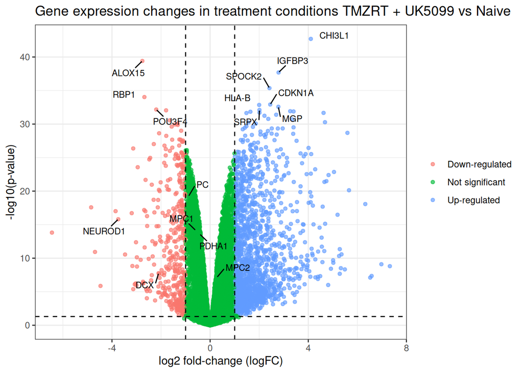

```r
# Build volcano plot data, using FDR and log-fold change to determine direction
volcano_df <- tab_combo_vs_naive %>%
  mutate(Significant = FDR < 0.05,
         direction = case_when(
           FDR < 0.05 & logFC > 1 ~ "Up-regulated",
           FDR < 0.05 & logFC < -1 ~ "Down-regulated",
           TRUE ~ "Not significant"))

# Select the top genes to label
label_volcano <- volcano_df %>%
  filter(gene %in% highlight_genes | rank(FDR) <= 10)

# Build volcano plot
ggplot(volcano_df, aes(x = logFC, y = -log10(PValue))) +
  geom_point(aes(color = direction), alpha = 0.65, size = 1.3) +
  geom_vline(xintercept = c(-1, 1), linetype = "dashed") +
  geom_hline(yintercept = -log10(0.05), linetype = "dashed") +
  geom_text_repel(data = label_volcano, aes(label = gene), size = 3, box.padding = 0.5, max.overlaps = Inf) +
  theme_bw() +
  labs(
    title = "Gene expression changes in treatment conditions TMZRT + UK5099 vs Naive",
    x = "log2 fold-change (logFC)",
    y = "-log10(p-value)",
    color = NULL
  )
```

**Figure 6: Volcano plot of differential expression results for combination treatment (TMZ-RT + UK5099) vs. Naive.** Each point represents one gene tested for differential expression using `edgeR`’s quasi-likelihood framework. The x-axis shows the estimated log2 fold-change between TMZ-RT + UK5099 and therapy-naive conditions, and the y-axis shows the strength of evidence against the null hypothesis of -log10(p-value). Genes are coloured by the direction of change using thresholds of FDR < 0.05 and |logFC| > 1 (up-regulated, down-regulated, or not significant). Dashed vertical lines indicate the fold-change threshold, and the dashed horizontal line indicates the p-value threshold. Selected genes are labelled, including the top 10 hits by FDR and genes of interest from the study (NEUROD1, DCX, MPC1, MPC2, PC, PDHA1).

In Figure 6, there is again a strong differential expression signal, with many genes showing large effect sizes and high statistical significance. The main takeaway from this plot, however, is that it does not follow the findings of the study. Key genes MPC1, MPC2, PDHA1, and PC are all not significant in this plot, but NEUROD1 and DCX are still down-regulated. This suggests that the combined treatment is not able to restore expression to the neural differentiation markers, and is therefore unable to prevent recurrence.

### Heatmap of top genes

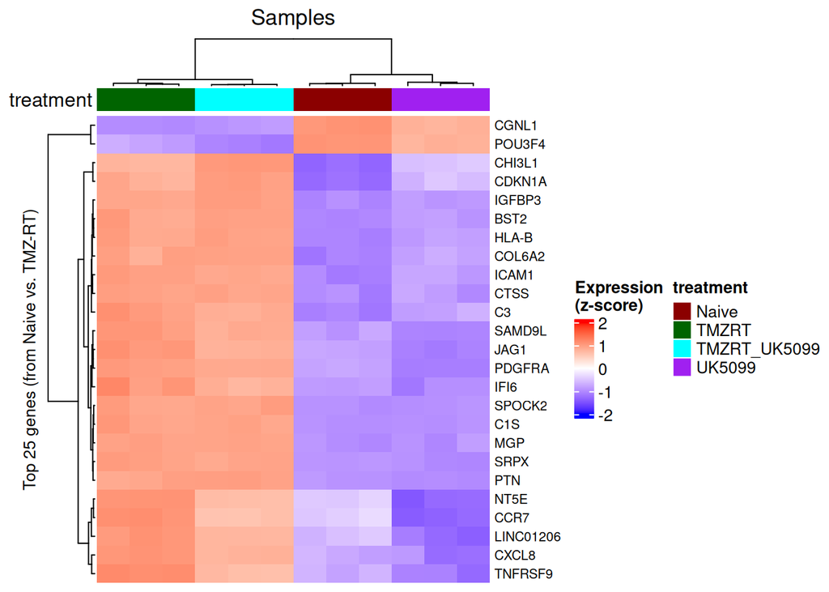

```r
# Load in relevant libraries
library("ComplexHeatmap")
library("circlize")

# Select the top 25 genes by FDR for the heatmap
top_hits <- tab_tmzrt_vs_naive %>%
  arrange(FDR, PValue) %>%
  slice_head(n = 25)
top_genes <- top_hits$gene

# Compute logCPM from the filtered DGEList for better visualisation
logcpm <- cpm(d, log = TRUE, prior.count = 1)

# Keep only the top 25 genes
hm_mat <- logcpm[top_genes, , drop = FALSE]

# Calculate the z-score per gene for heatmap
hm_z <- t(scale(t(hm_mat)))

# Annotation for treatment labelling on heatmap
annotation_col <- data.frame(treatment = samples$treatment)
rownames(annotation_col) <- samples$sample

# Define colours for treatments
treat_cols <- c(
  "Naive" = "darkred",
  "TMZRT" = "darkgreen",
  "TMZRT_UK5099" = "cyan",
  "UK5099" = "purple"
)

ha <- HeatmapAnnotation(
  treatment = annotation_col$treatment,
  col = list(treatment = treat_cols),
  annotation_name_side = "left"
)

# Choose colour for z-scores
col_fun <- colorRamp2(c(-2, 0, 2), c("blue", "white", "red"))

# Create heatmap
Heatmap(
  hm_z,
  name = "Z-score",
  col = col_fun,
  top_annotation = ha,
  show_row_names = TRUE,
  row_names_gp = grid::gpar(fontsize = 8),
  show_column_names = FALSE,
  cluster_rows = TRUE,
  cluster_columns = TRUE,
  row_title = "Top 25 genes (from Naive vs. TMZ-RT)",
  row_title_gp = grid::gpar(fontsize = 10),
  column_title = "Samples",
  heatmap_legend_param = list(title = "Expression\n(z-score)")
)
```

**Figure 7: Heatmap of the top 25 differentially expressed genes in TMZRT vs. Naive.** Rows represent the top 25 genes ranked by FDR from the TMZ-RT vs Naive `edgeR` quasi-likelihood test, and columns represent samples. Expression values are shown as per-gene z-scores calculated from logCPM values (blue = lower relative expression, red = higher relative expression). Samples are hierarchically clustered, and the treatment group for each sample is indicated by the annotation bar at the top.

Figure 7 shows that the top 25 genes identified from the TMZ-RT vs. Naive comparison separate the samples into distinct clusters, with naive samples grouping together with UK5099 treated cells, and TMZ-RT treated samples grouping separately. This is similar to the results of the volcano plots above, where treatment with UK-5099 results does not affect expression levels of most genes. It also shows that, at least in these 25 genes, TMZ-RT did not show a meaningful difference to the combined treatment of TMZ-RT + UK5099, similar to the results we saw in Figure 6, where adding the metabolic intervention did not modify expression of most genes when compared to TMZ-RT alone.

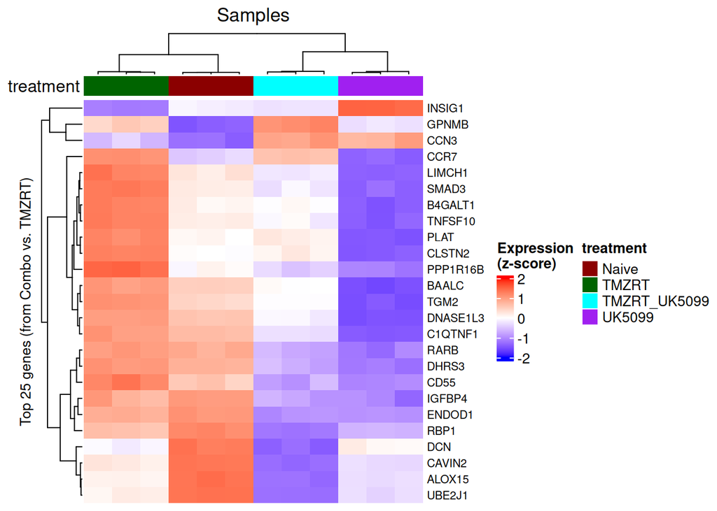

```r
# Select the top 25 genes by FDR for the heatmap
top_hits <- tab_combo_vs_tmzrt %>%
  arrange(FDR, PValue) %>%
  slice_head(n = 25)
top_genes <- top_hits$gene

# Compute logCPM from the filtered DGEList for better visualisation
logcpm <- cpm(d, log = TRUE, prior.count = 1)

# Keep only the top 25 genes
hm_mat <- logcpm[top_genes, , drop = FALSE]

# Calculate the z-score per gene for heatmap
hm_z <- t(scale(t(hm_mat)))

# Create heatmap
Heatmap(
  hm_z,
  name = "Z-score",
  col = col_fun,
  top_annotation = ha,
  show_row_names = TRUE,
  row_names_gp = grid::gpar(fontsize = 8),
  show_column_names = FALSE,
  cluster_rows = TRUE,
  cluster_columns = TRUE,
  row_title = "Top 25 genes (from Combo vs. TMZRT)",
  row_title_gp = grid::gpar(fontsize = 10),
  column_title = "Samples",
  heatmap_legend_param = list(title = "Expression\n(z-score)")
)
```

**Figure 8: Heatmap of the top 25 differentially expressed genes in TMZRT + UK5099 vs TMZRT.** Rows represent the top 25 genes ranked by FDR from the `edgeR` quasi-likelihood test comparing TMZRT + UK5099 to TMZRT alone, and columns represent samples. Expression values are shown as per-gene z-scores calculated from logCPM values (blue = lower relative expression, red = higher relative expression). Samples are hierarchically clustered, and treatment group is indicated by the annotation bar at the top.

Figure 8 reveals more differences in naive versus UK5099 treatment, and TMZ-RT versus combined treatments that were questioned in Figure 7. Here, I can see clear differences between these groups in these 25 genes, indicating that there are clear expression differences in at least some genes, although the key genes are not changed significantly, as shown in Figure 6.

## Conclusion

In this report, I performed a bulk RNA-seq differential expression analysis using a publicly available GBM dataset (GEO accession number: `GSE253464`) comparing therapy-naive cells to TMZ-RT exposure and metabolic inhibition with the MPC inhibitor UK5099. Raw counts were quality controlled, filtered, and normalized using TMM, followed by exploratory visualizations (boxplots, density plots, and MDS) to confirm sample structure and guide model design. Differential expression was then tested using `edgeR`’s quasi-likelihood framework, and results were summarized using significance thresholds (raw p-values and FDR), volcano plots, and heatmaps to highlight treatment-driven expression changes. Overall, the results are mixed when compared against the study. It aligned in showing that TMZ-RT and UK5099 treatments separately did not restore the expression of NEUROD1 and DCX. However, even samples that underwent combined treatment did not restore the expression, contrary to the paper’s findings.

### Associated questions

1. Why is the dataset of interest to you? This study and dataset is of interest to me because my current research project with Dr. Federico Gaiti also focuses on glioblastoma and the recurrent property of the cancer, as our attempts are in resolving primary from recurrent tumour cell families in phylogenies.
2. What are the control and test conditions of the dataset? The main treatment conditions tested were therapy-naive GBM cells versus GBM cells exposed to a concurrent TMZ-RT regimen. They also tested metabolic interventions by inhibiting MPC with UK-5099, both alone and adjuvant after TMZ-RT.
3. How many samples in each of the conditions of your dataset? Next, I also wanted to investigate the samples. Each treatment condition has 3 duplicates, over 4 different treatment conditions.
4. Were there expression values that were not unique for specific genes? How did you handle these? There are also some genes that appear to be formatted incorrectly - their HGNC ID has only numerical characters, and their formatting appears to be wrong on the table. I will remove these rows and genes from the table.
5. Were there expression values that could not be mapped to current HUGO symbols? The initial dataset from GEO uses the HGNC symbols for its gene IDs, so all genes have a corresponding HUGO symbol.
6. Were there any outliers in your dataset? How were they handled in the originating paper? How many outliers were removed? I then looked at the library size of each sample to ensure that there are no samples that have a relatively low read count. The library size table shows that it ranges from 1.3151306^{7} to 4.1906773^{7}, but all samples have normal read counts when compared to each other. Therefore, we will not remove any samples. The paper also did not mention any sample outliers.
7. How did you handle replicates? I will handle replicates by keeping all samples as separate observations rather than averaging counts within each treatment group. This will improve statistical power and provides more reliable differential expression testing.
8. What is the final coverage of your dataset? In this step, we will also filter out lowly expressed genes using `edgeR`’s `filterByExpr()` function. This will remove genes that have relatively low read counts, as was mentioned during the cleaning steps above. This resulted in 15,630 genes being kept across 12 samples, filtering out 28,154 lowly expressed genes.

## References

Chen, Yunshun, Lizhong Chen, Aaron T L Lun, Pedro Baldoni, and Gordon K Smyth. 2025. “edgeR V4: Powerful Differential Analysis of Sequencing Data with Expanded Functionality and Improved Support for Small Counts and Larger Datasets.” *Nucleic Acids Research* 53 (2): gkaf018. https://doi.org/10.1093/nar/gkaf018.

Davis, Sean, and Paul Meltzer. 2007. “GEOquery: A Bridge Between the Gene Expression Omnibus (GEO) and BioConductor.” *Bioinformatics* 14: 1846–47. https://doi.org/10.1093/bioinformatics/btm254.

Durinck, Steffen, Yves Moreau, Arek Kasprzyk, et al. 2005. “BioMart and Bioconductor: A Powerful Link Between Biological Databases and Microarray Data Analysis.” *Bioinformatics* 21: 3439–40.

Evans, Ciaran, Johanna Hardin, and Daniel M Stoebel. 2017. “Selecting Between-Sample RNA-Seq Normalization Methods from the Perspective of Their Assumptions.” *Briefings in Bioinformatics* 19 (5): 776–92. https://doi.org/10.1093/bib/bbx008.

Gu, Zuguang. 2022. “Complex Heatmap Visualization.” *iMeta*, ahead of print. https://doi.org/10.1002/imt2.43.

Gu, Zuguang, Lei Gu, Roland Eils, Matthias Schlesner, and Benedikt Brors. 2014. “Circlize Implements and Enhances Circular Visualization in r.” *Bioinformatics*, ahead of print. https://doi.org/10.1093/bioinformatics/btu393.

Martell, Emma, Helgi Kuzmychova, Harshal Senthil, et al. 2025. “Disease Stage-Specific Role of the Mitochondrial Pyruvate Carrier Suppresses Differentiation in Temozolomide and Radiation-Treated Glioblastoma.” *Neuro-Oncology* 27 (5): 1193–209. https://doi.org/10.1093/neuonc/noaf008.

Morgan, Martin, and Marcel Ramos. 2025. *BiocManager: Access the Bioconductor Project Package Repository*. https://bioconductor.github.io/BiocManager/.

Müller, Kirill, and Hadley Wickham. 2025. *Tibble: Simple Data Frames*. https://tibble.tidyverse.org/.

Pedersen, Thomas Lin. 2025. *Patchwork: The Composer of Plots*. https://doi.org/10.32614/CRAN.package.patchwork.

Slowikowski, Kamil. 2024. *Ggrepel: Automatically Position Non-Overlapping Text Labels with ’Ggplot2’*. https://doi.org/10.32614/CRAN.package.ggrepel.

Wickham, Hadley. 2016. *Ggplot2: Elegant Graphics for Data Analysis*. Springer-Verlag New York. https://ggplot2.tidyverse.org.

Wickham, Hadley, Romain François, Lionel Henry, Kirill Müller, and Davis Vaughan. 2023. *Dplyr: A Grammar of Data Manipulation*. https://doi.org/10.32614/CRAN.package.dplyr.

Wickham, Hadley, Jim Hester, and Jennifer Bryan. 2025. *Readr: Read Rectangular Text Data*. https://doi.org/10.32614/CRAN.package.readr.

Wickham, Hadley, Davis Vaughan, and Maximilian Girlich. 2024. *Tidyr: Tidy Messy Data*. https://doi.org/10.32614/CRAN.package.tidyr.

Xie, Yihui. 2014. “Knitr: A Comprehensive Tool for Reproducible Research in R.” In *Implementing Reproducible Computational Research*, edited by Victoria Stodden, Friedrich Leisch, and Roger D. Peng. Chapman; Hall/CRC.

Xie, Yihui, Christophe Dervieux, and Emily Riederer. 2020. *R Markdown Cookbook*. Chapman; Hall/CRC. https://bookdown.org/yihui/rmarkdown-cookbook.